# MPP-E1180 Lecture 9: Statistical Modeling with R

18 November 2016

## Objectives for the class

- Assignment 3
- Review
- Intro to the general syntax for statistical modelling in R.
- Specific examples using:
  - Normal linear regression
  - Logistic regression
  - Panel data

## Collaborative Research Project (1)

**Purposes**: Pose an interesting research question and try to answer it using data analysis and standard academic practices. Effectively communicate your results to a **variety of audiences** in a **variety of formats**.

**Deadline**:

- Presentation: In-class 2 December
- Website/Paper: 16 December 2016

## Collaborative Research Project (2)

The project can be thought of as a 'dry run' for your thesis with multiple presentation outputs.

Presentation: 10 minutes **maximum**. **Engagingly** present your research question and key findings to a general academic audience (fellow students).

Paper: 5,000 words maximum. **Standard academic paper**, properly cited laying out your research question, literature review, data, methods, and findings.

Website: An engaging website designed to convey your research to **a general audience**.

## Collaborative Research Project (3)

As always, you should **submit one GitHub repository** with all of the materials needed to **completely reproduce** your data gathering, analysis, and presentation documents.

**Note**: Because you've had two assignments already to work on parts of the project, I expect **high quality work**.

## Collaborative Research Project (4)

Find one other group to be a **discussant** for your presentation.

The discussants will provide a quick (max 2 minute) critique of your presentation–ideas for things you can improve on your paper.

## Office hours

I will have normal office hours every week for the rest of the term **except 9 December**.

Please take advantages of this opportunity to **improve your final project**.

## Review

- What is **web scraping**? What are some of tools R has for web scraping?
- What are **regular expressions** (give at least two examples)? Why are they useful?
- What dplyr function can you use to create a **new variable** in a data frame by running a command on values from groups in that data frame?

## Review

- What is the data-ink ratio? Why is it important for effective plotting.
- Why should you avoid using the **size** of circles to have meaning about continuous variables?
- Why not use red-green colour contrasts to indicate contrasting data?
- How many decimal places should you report in a table and why?

## Statistical Modelling in R

**Caveat**: We are **definitely not** going to cover anywhere near R's full capabilities for statistical modeling.

We are also **not going to cover** all of the **modeling concerns/diagnostics** you need to consider when using a given model.

You will need to **rely on your other stats courses** and **texts**.

## What are we going to do?

- Discuss the basic syntax and capabilities in R for estimating normal linear and logistic regressions.
- Basic model checking in R.
- Discuss basic ways of interpreting and presenting results.

## The basic model

Most statistical models you will estimate are from a general class (**Generalised Linear Model**) that has **two parts**:

**Stocastic Component** (e.g. randomly determined) assumes the dependent variable \(Y_{i}\) is generated from as a random draw from the probability density function:

\[ Y_{i} \sim f(\theta_{i},\: \alpha) \]

- \(\theta_{i}\): parameter vector of the part of the function that **varies between observations**.
- \(\alpha\): matrix of **non-varying parameters**.

Sometimes referred to as the '**error structure**'.

## The basic model

The **Systematic Component** indicating how \(\theta_{i}\) varies across observations depending on values of the explanatory variables and (often) some constant:

\[ \theta_{i} = g(X_{i},\: \beta) \]

- \(X_{i}\): a \(1\: \mathrm{x}\: k\) vector of **explanatory variables**.
- \(\beta\): a \(1\: \mathrm{x}\: k\) vector of **parameters** (i.e. coefficients).
- \(g(.,.)\): the **link function**, specifying how the explanatory variables and parameters are translated into \(\theta_{i}\).

## Today

Today we will cover two variations of this general model:

- linear-normal regression (i.e. ordinary least squares)
- logit model

## Linear-normal regression

For continuous dependent variables assume that \(Y_{i}\) is from the **normal distribution** (\(N(.,.)\)).

Set the main parameter vector \(\theta_{i}\) to the **scalar mean** of: \(\theta_{i} = E(y_{i})= \mu_{i}\).

- **Scalar**: a real number (in R-language: a vector of length 1)

Assume the ancillary parameter matrix is the scalar homoskedastic variance: \(\alpha = V(Y_{i}) = \sigma^2\).

- **Homoskedastic variance**: variance does not depend on the value of \(x\). The standard deviation of the error terms is constant across values of \(x\).

Set the systematic component to the linear form: \(g(X_{i},\: \beta) = X_{i}\beta = \beta_{0} + X_{i1}\beta_{1} + \ldots\).

## Linear-normal regression

So:

\[ Y_{i} \sim N(\mu_{i},\: \sigma^2), \:\:\: \mu_{i} = X_{i}\beta \]

## Logit regression

For binary data (e.g. 0, 1) we can assume that the stochastic component has a Bernoulli distribution.

The main parameter is \(\pi_{i} = \mathrm{Pr}(Y_{i} = 1)\).

The systematic component is set to a logistic form: \(\pi_{i} = \frac{1}{1 + e^{-X_{i}\beta}}\).

So:

\[ Y_{i} \sim \mathrm{Bernoulli}(\pi_{i}), \:\:\: \pi_{i} = \frac{1}{1 + e^{-X_{i}\beta}} \]

## Example error structure families and link functions

| Error Family | Canonical link |
| --- | --- |
| Normal | identity |
| binomial | logit |
| poisson | log |

## R syntax

The general syntax for estimating statistical models in R is:

```r
response variable ~ explanatory variable(s)
```

Where '`~`' reads 'is modelled as a function of'.

In the Generalised Linear Model context, either explicitly or implicitly:

```r
response variable ~ explanatory variable(s), family = error family
```

## Model functions

We use model functions to specify the model structure.

Basic model functions include:

- `lm`: fits a linear model where \(Y\) is assumed to be normally distributed and with homoskedastic variance.
- `glm`: allows the fitting of many Generalised Linear Models. Lets you specify the error `family`.
- `plm` (package and function): panel data Linear Models
- `pglm` (package and function): panel data Generalised Linear Models

## Example of `lm`

Example data *Prestige* (example based on http://www.princeton.edu/~otorres/Regression101R.pdf).

The observations are **occupations** and the dependent variable is a score of each occupation's **prestige**.

```r
library(car)
data(Prestige)
```

## Examine correlation matrix

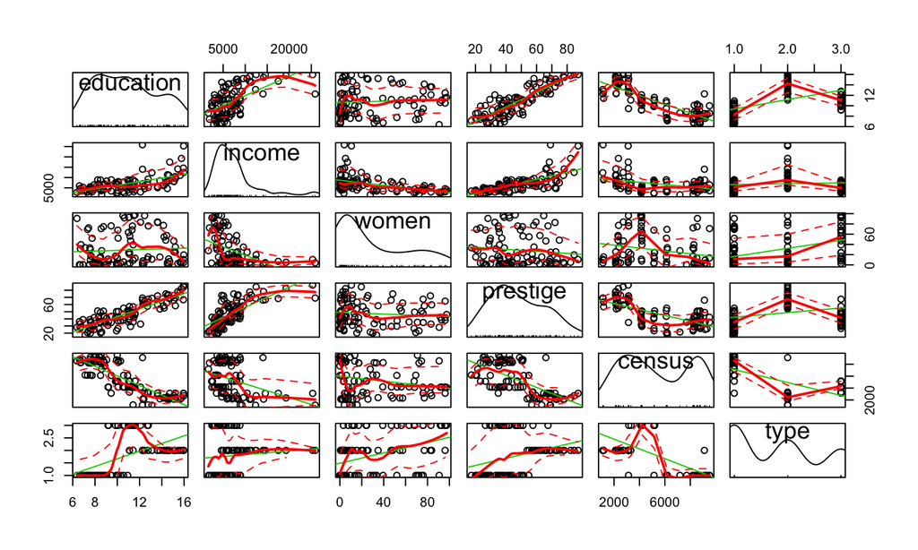

```r
car::scatterplotMatrix(Prestige)
```

## Example of `lm`

Estimate simple model (education is in years):

```r
M1 <- lm(prestige ~ education, data = Prestige)
```

```r
summary(M1)
```

```
##
## Call:
## lm(formula = prestige ~ education, data = Prestige)
##
## Residuals:
##      Min       1Q   Median       3Q      Max
## -26.0397  -6.5228   0.6611   6.7430  18.1636
##
## Coefficients:
##             Estimate Std. Error t value Pr(>|t|)
## (Intercept)  -10.732      3.677  -2.919  0.00434 **
## education      5.361      0.332  16.148  < 2e-16 ***
## ---
## Signif. codes:  0 '***' 0.001 '**' 0.01 '*' 0.05 '.' 0.1 ' ' 1
##
## Residual standard error: 9.103 on 100 degrees of freedom
## Multiple R-squared:  0.7228, Adjusted R-squared:   0.72
## F-statistic: 260.8 on 1 and 100 DF,  p-value: < 2.2e-16
```

## Confidence intervals of parameter point estimates

Note: **Always prefer estimation intervals** over point estimates.

Deal with your **uncertainty**!

About **95%** of the time the population parameter will be within **about 2 standard errors** of the point estimate.

Using **Central Limit Theorem** (at least about 50 observations and the data is not extremely skewed):

\[ CI\_95 = \mathrm{point\: estimate} \pm 1.96 * SE \]